# Basics stats in R

François

2023-10-19

**Note that this is a very basic guide - not the solution to all your stats issues! A lot of things are simplified or not touched upon!**

### Data

plenty of data sets are available in R; you can download them via packages. this is nice because it’s going to work on your computer as well

```r
iris = iris
head(iris)
```

```
##   Sepal.Length Sepal.Width Petal.Length Petal.Width Species
## 1          5.1         3.5          1.4         0.2  setosa
## 2          4.9         3.0          1.4         0.2  setosa
## 3          4.7         3.2          1.3         0.2  setosa
## 4          4.6         3.1          1.5         0.2  setosa
## 5          5.0         3.6          1.4         0.2  setosa
## 6          5.4         3.9          1.7         0.4  setosa
```

### Basic stats

```r
mean(iris$Sepal.Width , na.rm=T) #  na.rm=T ignores missing values
```

```
## [1] 3.057333
```

```r
median(iris$Sepal.Width)
```

```
## [1] 3
```

```r
sd(iris$Sepal.Width)
```

```
## [1] 0.4358663
```

You are free to use the base function but we can code this manually to better understand the formula

Here it is:

$$\text{Sample Variance} = \frac{1}{n-1} \sum_{i=1}^{n}(x_i - \bar{x})^2$$

Where:

- $n$ is the number of data points.
- $x_i$ represents each data point.
- $\bar{x}$ is the mean of the data points.

```r
variance = function(data) {
  if(!is.vector(data)) {
    stop("This function only works with a vector")
    }  #error in case data is not correctly formatted

  mean = mean(data, na.rm = T)

  denominator =  (length(data)-1) # (n-1) is the denominator in the variance formula.
  numerator = sum(
    (data-mean)**2
  )

  return(numerator/denominator) ## aplying the formula
}
```

$\sigma$ is the square root of the variance so to the power of 1/2 is the same as square root, 1/3 cubic root etc.

```r
variance(iris$Sepal.Width)
```

```
## [1] 0.1899794
```

```r
variance(iris$Sepal.Width)**(1/2) ## this is the sd.
```

```
## [1] 0.4358663
```

```r
variance(iris$Sepal.Width)**(1/2) == sd(iris$Sepal.Width) # check if we did it correctly?
```

```
## [1] TRUE
```

$\sigma$, mean & median only tell you so much about the data graphs are always a nice tool

### plots

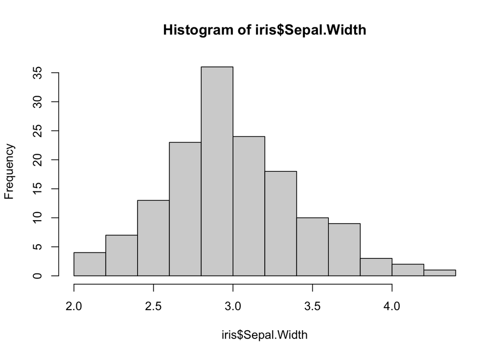

```r
hist(iris$Sepal.Width)
```

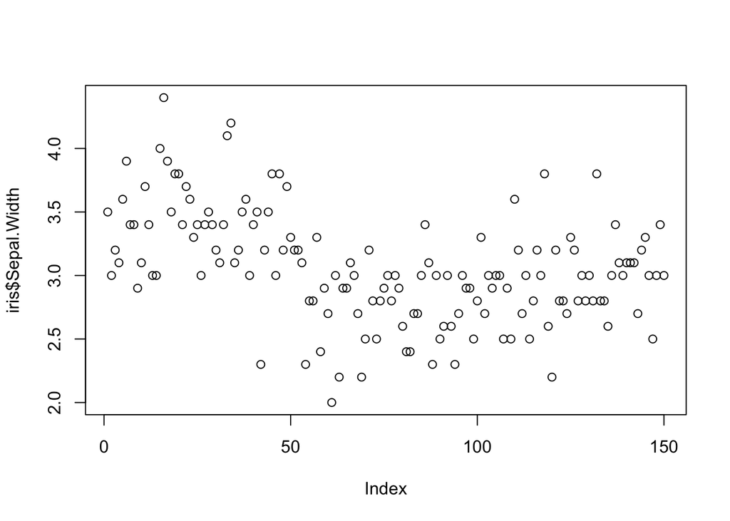

```r
plot(iris$Sepal.Width)
```

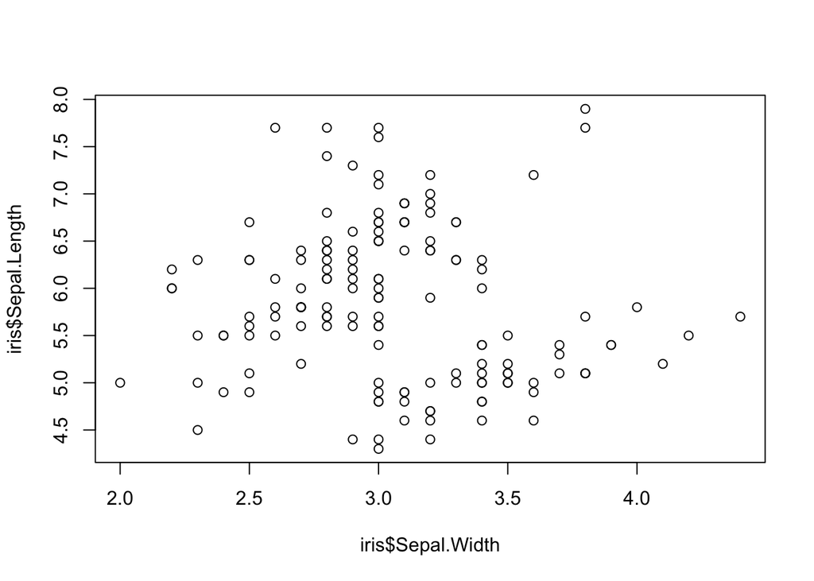

```r
plot(iris$Sepal.Width, iris$Sepal.Length)
```

base plots are easy but don’t have tons of options ggplot has a bit of a learning curve but can provide paper worthy papers in minutes.

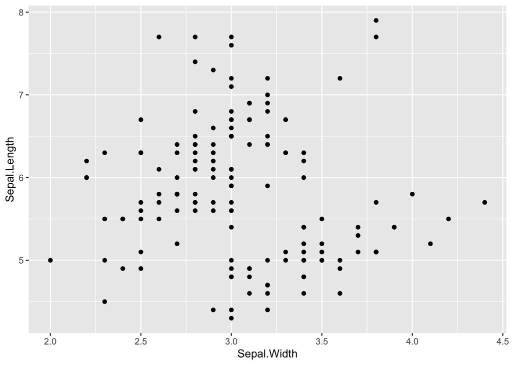

```r
ggplot( data = iris,
        map = aes(x = Sepal.Width, y = Sepal.Length)) +
  geom_point()
```

plot looks the same because we didn’t use any ggplot features just yet.

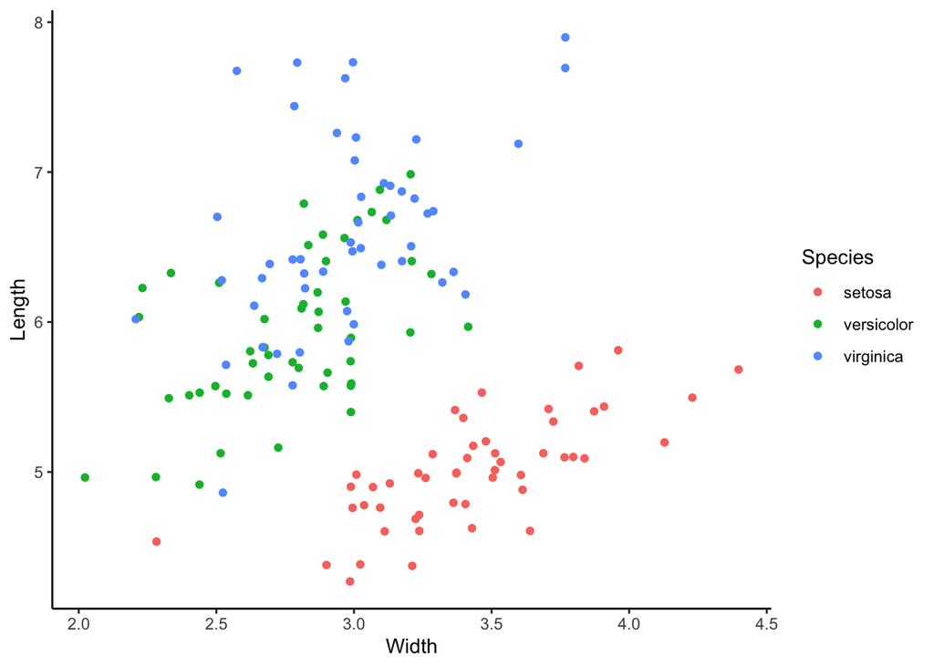

```r
ggplot( data = iris,
        map = aes(x = Sepal.Width, y = Sepal.Length, color = Species) ) +
  #color colors the points in their respctiv species
  geom_jitter() + theme_classic() +xlab("Width") + ylab("Length")
```

```r
#geom_jitter gets rid of the grid look whilst mostly not changing the data.
```

here we are able to see that there are 3 clusters something that wasn’t clear from just the mean/median/sd

### t-tests

While figures are visually appealing, they can sometimes lead to misinterpretations. Therefore, I prefer to rely on formal statistical tests.

In the case of the Iris dataset, it is evident that there are differences among species. let’s try it out.

```r
setosa = iris[iris$Species == "setosa", "Sepal.Width"] # here I select the df that where the species row are equal to "setosa"
virginica = iris[iris$Species == "virginica","Sepal.Width"] # same for viriginica
versiclors = iris[iris$Species == "versicolor","Sepal.Width"] # same for viriginica
```

within “[]”the space before the “,” refers to the rows & after to the columns

```r
t.test(setosa, mu = 3)  # this tells us that the mean is significantly different from 3
```

```
##
##  One Sample t-test
##
## data:  setosa
## t = 7.9839, df = 49, p-value = 2.022e-10
## alternative hypothesis: true mean is not equal to 3
## 95 percent confidence interval:
##  3.320271 3.535729
## sample estimates:
## mean of x
##     3.428
```

```r
t.test(virginica, versiclors) #
```

```
##
##  Welch Two Sample t-test
##
## data:  virginica and versiclors
## t = 3.2058, df = 97.927, p-value = 0.001819
## alternative hypothesis: true difference in means is not equal to 0
## 95 percent confidence interval:
##  0.07771636 0.33028364
## sample estimates:
## mean of x mean of y
##     2.974     2.770
```

1. **P-value**: The p-value is a measure of the evidence against a null hypothesis. It indicates the probability of observing the data (or more extreme results) if the null hypothesis were true.
2. **T-statistic**: The t-statistic is a test statistic used in hypothesis testing. It quantifies the difference between the sample mean and the population mean, normalized by the standard error.
3. **Degrees of Freedom (df)**: Degrees of freedom represent the number of values in the final calculation of a statistic that are free to vary. In the context of t-tests, it is related to the sample size and the assumptions of the test. The formula for degrees of freedom depends on the type of t-test (e.g., independent samples or paired samples).

### Correlations

Correlation analysis is also a nice tool to asses the relationship of 2 given variables Again base R functions exist for this

```r
cor(iris$Sepal.Length,iris$Sepal.Width)
```

```
## [1] -0.1175698
```

```r
cor.test(iris$Sepal.Length, iris$Sepal.Width)
```

```
##
##  Pearson's product-moment correlation
##
## data:  iris$Sepal.Length and iris$Sepal.Width
## t = -1.4403, df = 148, p-value = 0.1519
## alternative hypothesis: true correlation is not equal to 0
## 95 percent confidence interval:
##  -0.27269325  0.04351158
## sample estimates:
##        cor
## -0.1175698
```

Reminder:

$$\text{Pearson Correlation Coefficient (r)} = \frac{\sum_{i=1}^{n}(x_i -
\bar{x})(y_i - \bar{y})}{\sqrt{\sum_{i=1}^{n}(x_i - \bar{x})^2
\sum_{i=1}^{n}(y_i - \bar{y})^2}}$$

Where:

- $n$ is the number of data points.
- $x_i$ represents each data point in the first variable.
- $y_i$ represents each data point in the second variable.
- $\bar{x}$ is the mean of the first variable.
- $\bar{y}$ is the mean of the second variable.

```r
calculate_correlation <- function(x, y) {
  # Calculate the mean of x and y
  mean_x <- mean(x)
  mean_y <- mean(y)

  # Calculate the sum of the products of the differences
  sum_product_diff <- sum((x - mean_x) * (y - mean_y))

  # Calculate the sum of squared differences for x and y
  sum_square_diff_x <- sum((x - mean_x)^2)
  sum_square_diff_y <- sum((y - mean_y)^2)

  # Calculate the Pearson correlation coefficient
  correlation <- sum_product_diff / sqrt(sum_square_diff_x * sum_square_diff_y)

  return(correlation)
}

calculate_correlation(iris$Sepal.Length,iris$Sepal.Width)
```

```
## [1] -0.1175698
```

```r
cor(iris$Sepal.Length,iris$Sepal.Width)
```

```
## [1] -0.1175698
```

### Regressions!

Of course you know about regressions. Here we are able to do more than simply compare 2 variables as with a correlation or a t-test.

```r
library(stargazer)
mod1 =lm(data = iris,
   formula = Sepal.Width ~ Sepal.Length)

mod2 =lm(data = iris,
   formula = Sepal.Width ~ Sepal.Length + Petal.Width)

mod3 =lm(data = iris,
   formula = Sepal.Width ~ Sepal.Length + Petal.Width * Petal.Length)

mod4 =lm(data = iris,
   formula = scale(Sepal.Width) ~ scale(Sepal.Length) +scale(Petal.Width)+scale(Petal.Length) +
     scale(Petal.Width) * scale(Petal.Length))


stargazer(mod3,mod4, type = 'text')
```

```
##
## =====================================================================
##                                             Dependent variable:
##                                        ------------------------------
##                                        Sepal.Width scale(Sepal.Width)
##                                            (1)            (2)
## ---------------------------------------------------------------------
## Sepal.Length                            0.487***
##                                          (0.065)
##
## Petal.Width                              -0.103
##                                          (0.189)
##
## Petal.Length                            -0.589***
##                                          (0.059)
##
## Petal.Width:Petal.Length                0.128***
##                                          (0.029)
##
## scale(Sepal.Length)                                     0.925***
##                                                         (0.123)
##
## scale(Petal.Width)                                      0.659***
##                                                         (0.214)
##
## scale(Petal.Length)                                    -1.764***
##                                                         (0.274)
##
## scale(Petal.Width):scale(Petal.Length)                  0.394***
##                                                         (0.089)
##
## Constant                                1.809***       -0.377***
##                                          (0.308)        (0.101)
##
## ---------------------------------------------------------------------
## Observations                               150            150
## R2                                        0.581          0.581
## Adjusted R2                               0.569          0.569
## Residual Std. Error (df = 145)            0.286          0.657
## F Statistic (df = 4; 145)               50.172***      50.172***
## =====================================================================
## Note:                                     *p<0.1; **p<0.05; ***p<0.01
```

In regression analysis, t-statistics are utilized to determine the significance (or lack thereof) of individual coefficients, all other factors held constant. Meanwhile, the F-statistic assesses the overall model goodness-of-fit, and the R-squared (R²) quantifies how much variability the model can account for.

In the case of the final regression, it incorporates an interaction term involving two variables. The interpretation of the interaction term is crucial, just as understanding the meaning of both constituent parts is. From a statistical standpoint, an interaction is essentially a form of moderation.

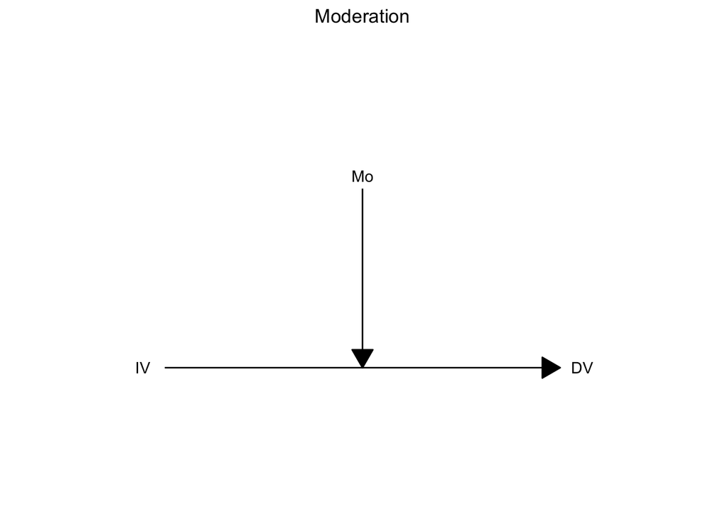

Mediation analysis can also be conducted using regression methods; however, to obtain standard errors and p-values, bootstrapping is commonly employed.

I won’t perform the bootstrapping here, but we covered it in class using the “process” package. Instead, I’ll provide you with the underlying rationale behind the package’s use.

Let’s consider an example where we aim to examine the mediated effect of Petal.Length on Sepal.Width, mediated through Petal.Width. In this context:

- Petal.Length serves as the independent variable (IV).
- Sepal.Width is the dependent variable (DV).
- Petal.Width functions as the mediator.

Through this mediation analysis, we explore how Petal.Length’s influence on Sepal.Width is channeled via the mediator, Petal.Width.

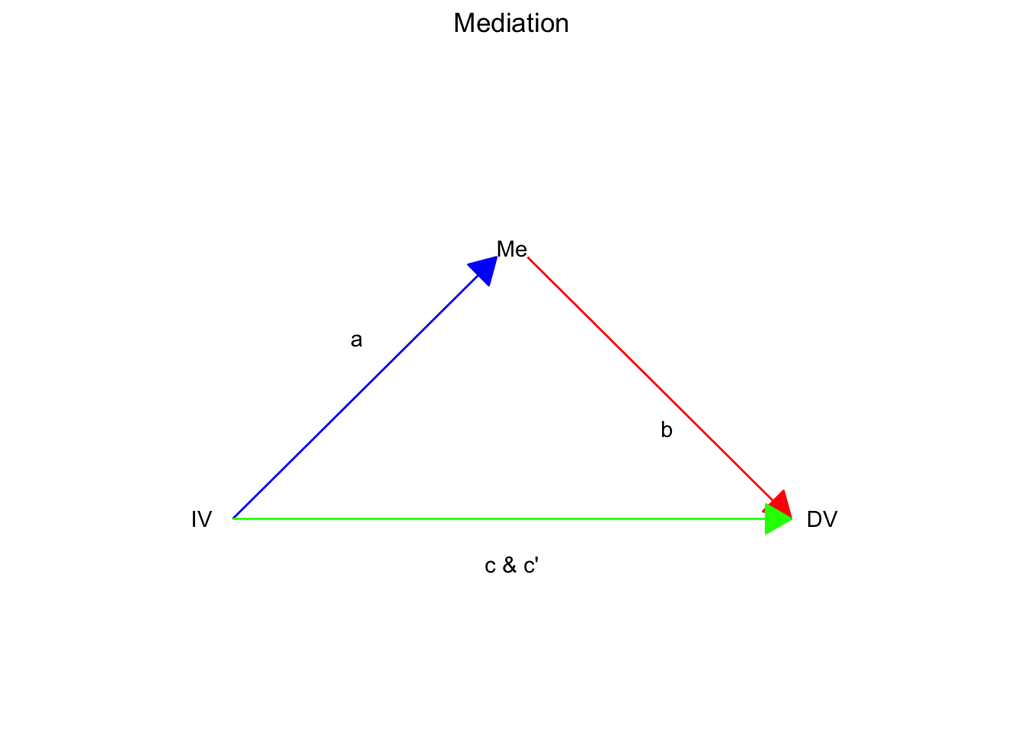

```r
path_c = lm(data = iris,
            Sepal.Width ~ Petal.Length)

path_a = lm(data = iris,
            Petal.Width ~ Petal.Length)

path_b = lm(data = iris,
            Sepal.Width ~ Petal.Length + Petal.Width)

indirect_effect = as.numeric(path_a$coefficients[2] * path_b$coefficients[3])
total_effect = as.numeric(path_c$coefficients[2])
direct_effect = total_effect - indirect_effect

print(paste(indirect_effect, 'is the indirect effect'))
```

```
## [1] "0.15135245778785 is the indirect effect"
```

```r
print(paste(direct_effect, 'is the direct effect'))
```

```
## [1] "-0.257137754047758 is the direct effect"
```

```r
print(paste(total_effect, 'is the total effect'))
```

```
## [1] "-0.105785296259908 is the total effect"
```

Mediation in statistics refers to a process where the relationship between an independent variable (IV) and a dependent variable (DV) is explained or mediated by one or more intermediate variables, often called mediators. Mediation analysis is used to understand the underlying mechanisms or pathways through which an IV influences a DV.

Three linear regression models (path_c, path_a, and path_b) are constructed:

- path_c: Regresses Sepal.Width on Petal.Length.
- path_a: Regresses Petal.Width on Petal.Length.
- path_b: Regresses Sepal.Width on Petal.Length and Petal.Width.

The total effect is obtained from the coefficient in path_c (Petal.Length → Sepal.Width). The direct effect is computed as the difference between the total effect and the indirect effect.

If we were to bootstrap, we’d run this n (a large number) times and look at the distribution of out effect sizes.